# ggsmartext: Smart Axis Labels for ggplot2

# 集中标注与热图标注（anno_mark 风格）

`connection_style = "diagonal"` 的几何直接对齐 `circlize` 与 `ComplexHeatmap::anno_mark()`：短垂线 → 斜线 → 短垂线 → 文字。配合”能一行放下一行、集中区域自动分层”的轨道策略，特别适合**只标注少数感兴趣的类别**。

## 集中在一段里的标签：自动分层

`which` 挑出来的标签如果只落在轴的一小段里，一行摊不开时 guide 会自动把它们分成多行、上下错开，每个标签仍然连回自己的刻度：

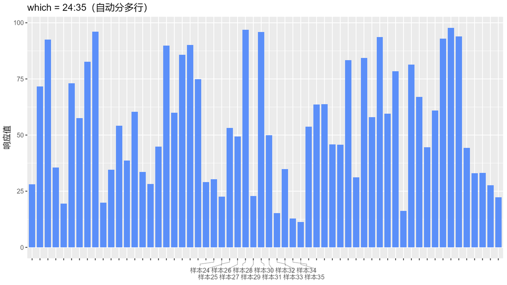

60 个类别里只标注 24~35：自动分成多行错开

```r
set.seed(5)
labs60 <- paste0("样本", 1:60)
df60 <- data.frame(
  sample = factor(labs60, levels = labs60),
  value = round(runif(60, 10, 100), 1)
)

ggplot(df60, aes(x = sample, y = value)) +
  geom_col(fill = "#5B8FF9", width = 0.8) +
  guides(x = guide_axis_smart(which = 24:35)) +
  labs(x = NULL, y = "响应值", title = "which = 24:35（自动分多行）") +
  theme_grey(base_size = 12)
```

想强制单行（纯 `anno_mark` 风格，标签沿轴摊开、引导线更长）就写 `nrow = 1`：

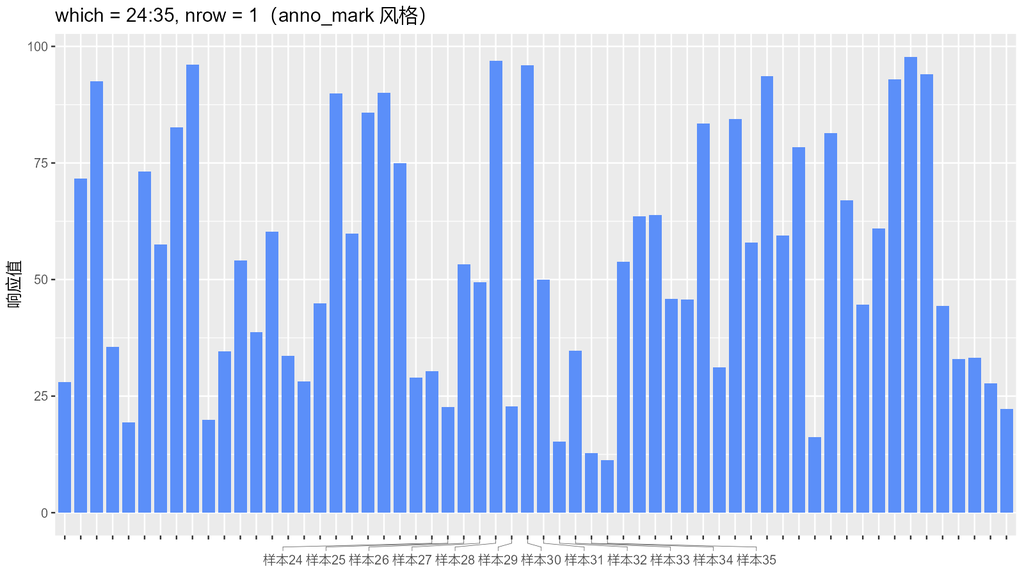

同样的标签用 nrow = 1 强制单行：沿轴摊开，引线更长

```r
ggplot(df60, aes(x = sample, y = value)) +
  geom_col(fill = "#5B8FF9", width = 0.8) +
  guides(x = guide_axis_smart(which = 24:35, nrow = 1)) +
  labs(x = NULL, y = "响应值", title = "which = 24:35, nrow = 1（anno_mark 风格）") +
  theme_grey(base_size = 12)
```

## 热图基因标注：`sec.axis` + `dup_axis()`

“只标注少数几行、其余不显示”是 `anno_mark()` 的典型场景。做法是：主轴关掉全部标签，再用 `dup_axis()` 复制一根副轴、把 smart guide 挂在副轴上。

下面用包内置的 **`airway_heatmap`** 数据画热图：它来自 GEO 上的真实 RNA-seq 实验（GSE52778， 人气道平滑肌细胞，4 株细胞系分别做地塞米松处理与对照）。这份数据已经处理好 ——表达过滤、`log2(CPM + 1)`、逐基因 z-score、按变异挑出 300 个基因并做层次 聚类排序（细节见 `?airway_heatmap`）——所以下面加载数据就能直接画图。

为了看清引导线长度和标签上下间距的分配，热图画成 **300 个基因**的竖长图， 并标注 20 个基因（顶部响应簇里连续 12 个 + 散布在中下部的 8 个）：

```r
## 内置数据：300 基因 x 8 样本的行 z-score 矩阵（已按层次聚类排序）
data(airway_heatmap, package = "ggsmartext")
df_gene <- airway_heatmap$df
mark    <- airway_heatmap$mark
```

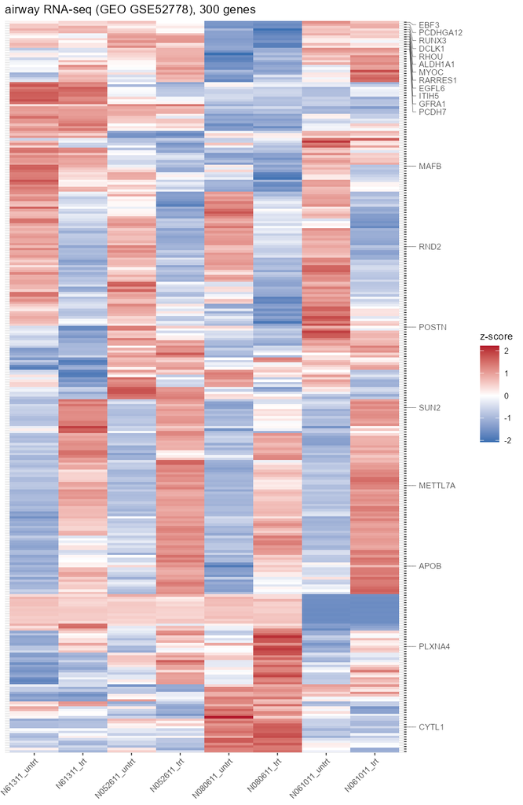

真实数据（GEO GSE52778）300 个基因的竖长热图：只标注 20 个基因，可以看到引导线长度和标签上下间距的自动分配

```r
ggplot(df_gene, aes(x = sample, y = gene, fill = z)) +
  geom_tile() +
  scale_y_discrete(
    guide = guide_none(),
    sec.axis = dup_axis(
      guide = guide_axis_smart(which = mark)
    )
  ) +
  scale_fill_gradient2(low = "#2166ac", mid = "white", high = "#b2182b",
                       midpoint = 0, name = "z-score") +
  labs(x = NULL, y = NULL, title = "airway RNA-seq (GEO GSE52778), 300 genes") +
  theme_grey(base_size = 9) +
  theme(axis.text.x = element_text(angle = 45, hjust = 1))
```

分面时每个面板的数据不同、标签也各自独立排布。这里把基因按”处理后上调/下调” 分成两个面板，每个面板只标注自己那一组里响应最强的 4 个基因（面板高度按基因数 自适应）：

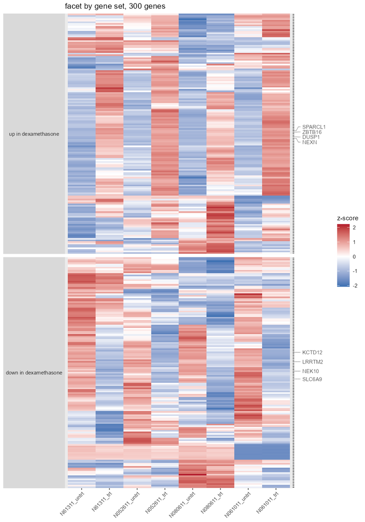

按基因集分面的热图：每个面板数据不同，标签各自独立排布

```r
## 每个面板（基因集）里响应最强的 4 个基因，数据里已经算好
mark_facet <- unlist(airway_heatmap$mark_by_set, use.names = FALSE)

ggplot(df_gene, aes(x = sample, y = gene, fill = z)) +
  geom_tile() +
  facet_grid(gene_set ~ ., scales = "free_y", space = "free_y", switch = "y") +
  scale_y_discrete(
    position = "right",
    guide = guide_axis_smart(
      which = function(labels, positions) labels %in% mark_facet
    )
  ) +
  scale_fill_gradient2(low = "#2166ac", mid = "white", high = "#b2182b",
                       midpoint = 0, name = "z-score") +
  labs(x = NULL, y = NULL, title = "facet by gene set, 300 genes") +
  theme_grey(base_size = 9) +
  theme(panel.grid = element_blank(),
        strip.placement = "outside",
        strip.text.y.left = element_text(angle = 0),
        axis.text.x = element_text(angle = 45, hjust = 1))
```

要点：

- 单面板：主轴用 `guide = guide_none()` 隐藏全部标签，`dup_axis()` 复制出来的副轴挂 `guide_axis_smart()`；
- 行数多（几百行）时最能看出效果：选中行如果挤在一起，标签会自动上下错开、 引导线各自连回自己的行；分散的标签则用较长的横线连过去；
- **分面（facet）**：每个面板按自己的数据独立选标签、独立排布；`which` 用 函数形式（`function(labels, positions)`）最稳，因为每个面板只会匹配到 自己存在的标签；
- 注意 `dup_axis()` 在分面图里不会逐面板绘制，分面时把 smart guide 直接挂在 `scale_y_discrete(position = "right", guide = ...)` 上即可；
- `airway_heatmap` 随包一起发布（`data/airway_heatmap.rda`），不依赖 `airway` 或 `SummarizedExperiment`；想看它是怎么从原始 counts 处理出来的， 可以按 `?airway_heatmap` 里的步骤用 `airway` 包复现。

# 长标签与角度：`angle`、`hjust`、`vjust`

标签文字很长时（比如”样本12（处理组A）“），靠多行错开仍然可能放不下，这时可以旋转标签。`angle` 支持 `0`、`45`、`90`，`NULL`（默认）表示继承主题里的 `axis.text.x` 角度。

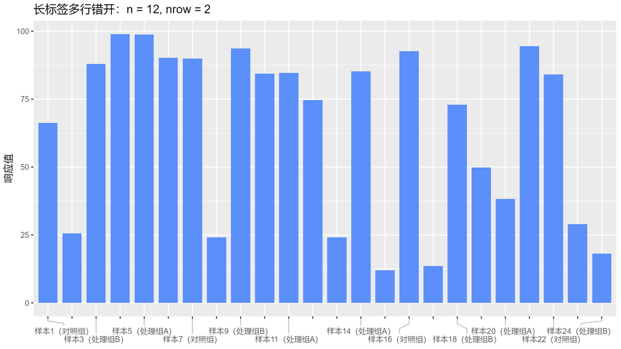

长标签 + 多行错开（不旋转）：n = 12, nrow = 2

```r
trt <- rep(c("对照组", "处理组A", "处理组B"), 8)
labs24 <- paste0("样本", 1:24, "（", trt, "）")
df24 <- data.frame(
  sample = factor(labs24, levels = labs24),
  value = round(runif(24, 10, 100), 1)
)

ggplot(df24, aes(x = sample, y = value)) +
  geom_col(fill = "#5B8FF9", width = 0.8) +
  guides(x = guide_axis_smart(n = 12, nrow = 2)) +
  labs(x = NULL, y = "响应值", title = "长标签多行错开：n = 12, nrow = 2") +
  theme_grey(base_size = 12)
```

[output not shown]

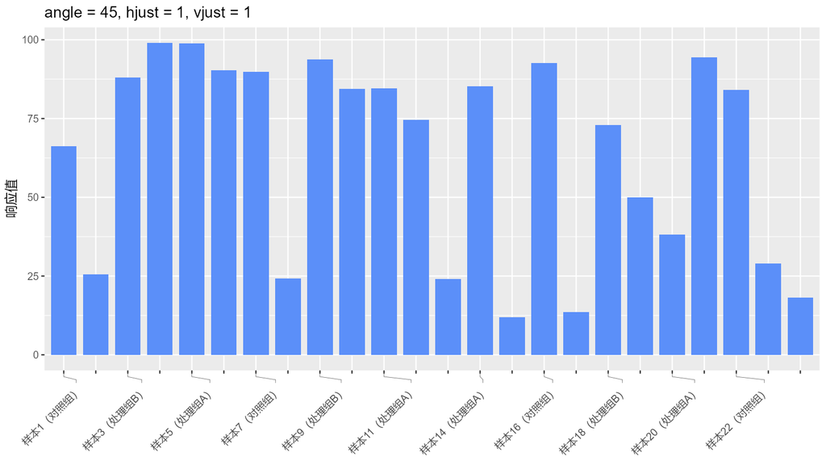

angle = 45：建议 nrow = 1，并配 hjust = 1、vjust = 1

```r
ggplot(df24, aes(x = sample, y = value)) +
  geom_col(fill = "#5B8FF9", width = 0.8) +
  guides(x = guide_axis_smart(n = 12, nrow = 1, angle = 45, hjust = 1, vjust = 1)) +
  labs(x = NULL, y = "响应值", title = "angle = 45, hjust = 1, vjust = 1") +
  theme_grey(base_size = 12)
```

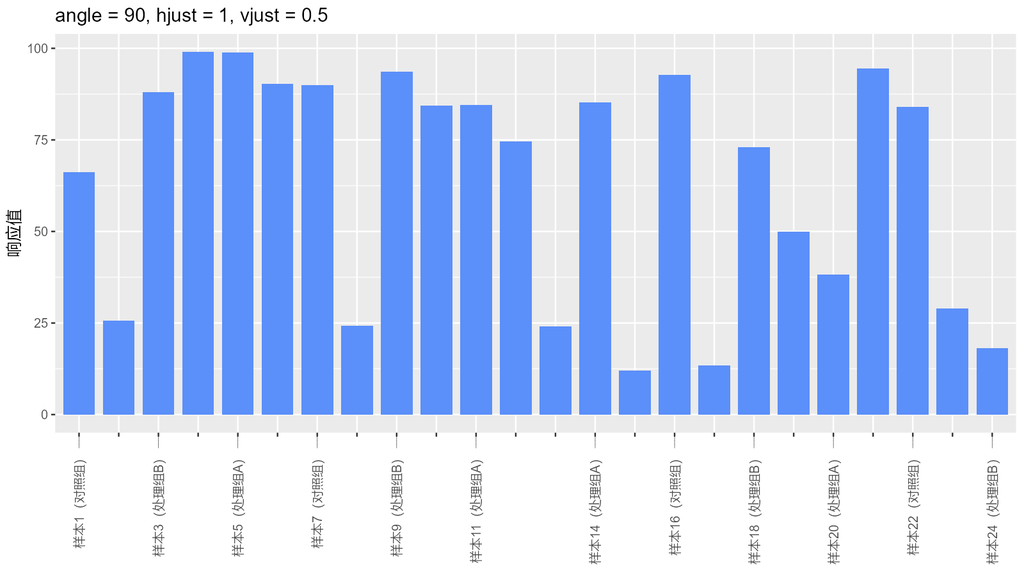

angle = 90：hjust = 1、vjust = 0.5 让标签贴着刻度排

```r
ggplot(df24, aes(x = sample, y = value)) +
  geom_col(fill = "#5B8FF9", width = 0.8) +
  guides(x = guide_axis_smart(n = 12, nrow = 1, angle = 90, hjust = 1, vjust = 0.5)) +
  labs(x = NULL, y = "响应值", title = "angle = 90, hjust = 1, vjust = 0.5") +
  theme_grey(base_size = 12)
```

`hjust` / `vjust` 直接传给标签文本的 grob；`NULL` 时按角度自动选一个合理值。实践上：

- `angle = 0`：保持默认即可；
- `angle = 45`：`hjust = 1, vjust = 1`（右对齐、贴着刻度）；
- `angle = 90`：`hjust = 1, vjust = 0.5`。

# 连续轴也能用

`guide_axis_smart()` 不要求轴是离散的。连续轴通过 `scale_*_continuous(breaks = ...)` 把刻度设密以后，同样可以只显示其中一部分、并分多行：

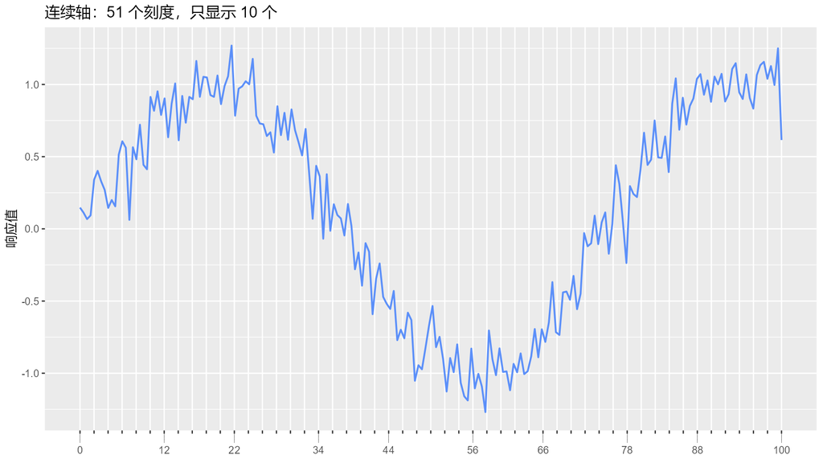

连续轴：51 个刻度标签，只显示 10 个

```r
set.seed(2024)
df_curve <- data.frame(
  x = seq(0, 100, length.out = 200),
  y = sin(seq(0, 100, length.out = 200) / 12) + rnorm(200, sd = 0.15)
)

ggplot(df_curve, aes(x, y)) +
  geom_line(colour = "#5B8FF9", linewidth = 0.8) +
  scale_x_continuous(breaks = seq(0, 100, by = 2), minor_breaks = NULL) +
  guides(x = guide_axis_smart(n = 10)) +
  labs(x = NULL, y = "响应值", title = "连续轴：51 个刻度，只显示 10 个") +
  theme_grey(base_size = 12)
```

连续轴上 `which` 的”字符匹配”针对的是**格式化之后**的刻度文本（例如 `"20"`），按位置写规则时用函数形式更稳。

# 与 facet、coord_flip、theme 配合

## facet：每个面板各自排布

分面以后每个面板都有自己的轴，guide 在每个面板里**独立计算**：面板变窄时自动多分几行， 标签也只从该面板自己的刻度里挑。

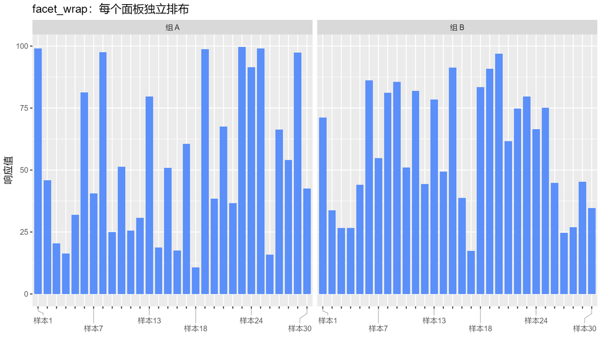

facet_wrap 的两个面板各自排布标签

```r
set.seed(7)
df_facet <- data.frame(
  sample = factor(paste0("样本", 1:30), levels = paste0("样本", 1:30)),
  value = round(runif(60, 10, 100), 1),
  group = rep(c("组 A", "组 B"), each = 30)
)

ggplot(df_facet, aes(x = sample, y = value)) +
  geom_col(fill = "#5B8FF9", width = 0.8) +
  facet_wrap(~ group, scales = "free_x") +
  guides(x = guide_axis_smart(n = 6, nrow = 2)) +
  labs(x = NULL, y = "响应值", title = "facet_wrap：每个面板独立排布") +
  theme_grey(base_size = 12)
```

### 自由刻度：每个面板只标自己的标签

`scales = "free_x"`（或 `free_y`）时各面板的类别不同。`which` 里一次写全所有面板想标的标签即可， 每个面板只画自己这里存在的那些；**某面板里不存在的标签会被静默跳过**，不会逐面板报错或警告：

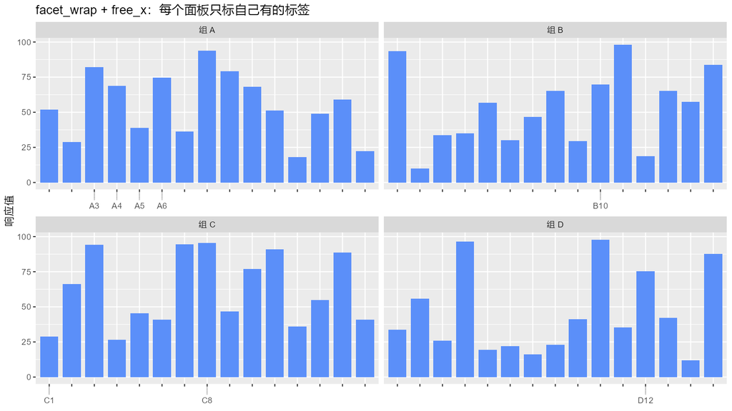

facet_wrap + free_x：每个面板只标自己有的标签

```r
set.seed(8)
df_facet_free <- data.frame(
  cat = factor(
    c(paste0("A", 1:15), paste0("B", 1:15), paste0("C", 1:15), paste0("D", 1:15)),
    levels = c(paste0("A", 1:15), paste0("B", 1:15), paste0("C", 1:15), paste0("D", 1:15))
  ),
  value = round(runif(60, 10, 100), 1),
  group = rep(c("组 A", "组 B", "组 C", "组 D"), each = 15)
)
mark_facet_free <- c("A3", "A4", "A5", "A6", "B10", "C1", "C8", "D12")

ggplot(df_facet_free, aes(cat, value)) +
  geom_col(fill = "#5B8FF9", width = 0.8) +
  facet_wrap(~ group, nrow = 2, scales = "free_x") +
  guides(x = guide_axis_smart(which = mark_facet_free)) +
  labs(x = NULL, y = "响应值",
       title = "facet_wrap + free_x：每个面板只标自己有的标签") +
  theme_grey(base_size = 11)
```

### 面板内拥挤：自动分层

一个面板里连续标很多标签时，guide 会在该面板内自动摊到多行；面板越窄，行数越多。下面强制 `nrow = 3`：

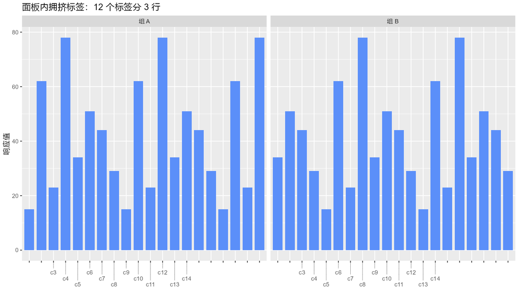

面板里连续标 12 个拥挤标签：自动分 3 行

```r
df_facet_crowd <- data.frame(
  cat = factor(paste0("c", 1:20), levels = paste0("c", 1:20)),
  value = rep(c(15, 62, 23, 78, 34, 51, 44, 29), length.out = 40),
  group = rep(c("组 A", "组 B"), each = 20)
)

ggplot(df_facet_crowd, aes(cat, value)) +
  geom_col(fill = "#5B8FF9", width = 0.8) +
  facet_wrap(~ group, nrow = 1) +
  guides(x = guide_axis_smart(which = 3:14, nrow = 3)) +
  labs(x = NULL, y = "响应值",
       title = "面板内拥挤标签：12 个标签分 3 行") +
  theme_grey(base_size = 11)
```

### facet_grid：共享轴只画一次，自由轴各画各的

`facet_grid` 行分面、x 轴共享时 guide 只画一次；`scales = "free_x"` 时每一列各自画一次：

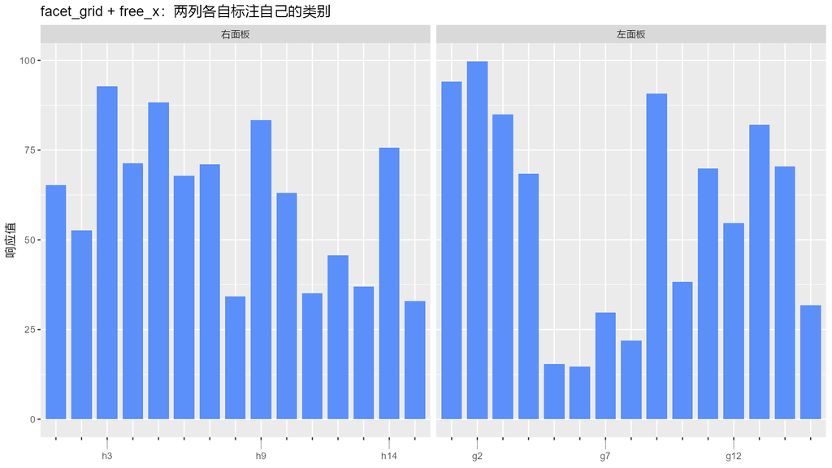

facet_grid：free_x 时每列各自标注

```r
df_facet_grid <- data.frame(
  cat = factor(c(paste0("g", 1:15), paste0("h", 1:15)),
               levels = c(paste0("g", 1:15), paste0("h", 1:15))),
  value = round(runif(30, 10, 100), 1),
  side = rep(c("左面板", "右面板"), each = 15)
)

ggplot(df_facet_grid, aes(cat, value)) +
  geom_col(fill = "#5B8FF9", width = 0.8) +
  facet_grid(. ~ side, scales = "free_x") +
  guides(x = guide_axis_smart(which = c("g2", "g7", "g12", "h3", "h9", "h14"))) +
  labs(x = NULL, y = "响应值",
       title = "facet_grid + free_x：两列各自标注自己的类别") +
  theme_grey(base_size = 11)
```

### 热图分面：右侧 y 轴每面板独立标注

热图分面时把 guide 挂在 `scale_y_discrete(position = "right")` 上即可；`free_y` 时每个面板 只标自己数据里的基因，拥挤的连续基因同样会自动分层：

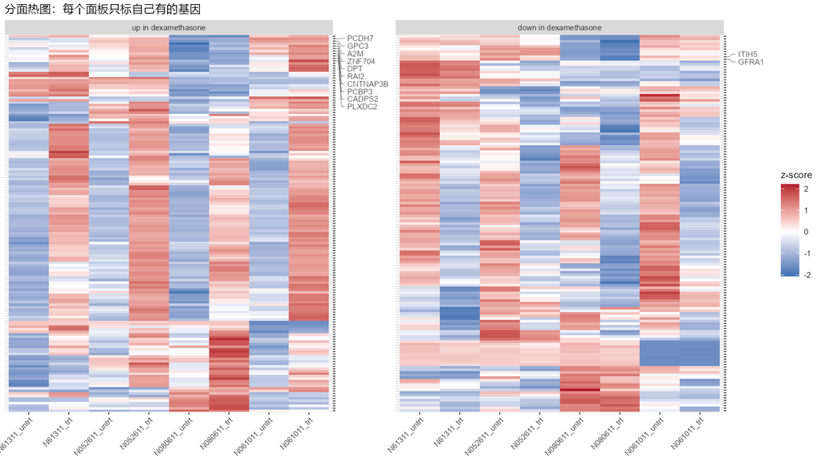

分面热图：用内置真实数据，每个面板独立标注自己的基因

```r
## 用包内置的真实 RNA-seq 数据（GEO GSE52778，300 基因 x 8 样本）
data(airway_heatmap, package = "ggsmartext")
df_facet_heat <- airway_heatmap$df
mark_wrap <- airway_heatmap$genes$gene[10:21]   # 顶部响应簇里连续的 12 个基因

ggplot(df_facet_heat, aes(sample, gene, fill = z)) +
  geom_tile() +
  facet_wrap(~ gene_set, nrow = 1, scales = "free_y") +
  scale_y_discrete(
    position = "right",
    guide = guide_axis_smart(which = mark_wrap)
  ) +
  scale_fill_gradient2(low = "#2166ac", mid = "white", high = "#b2182b",
                       midpoint = 0, name = "z-score") +
  labs(x = NULL, y = NULL,
       title = "分面热图：每个面板只标自己有的基因") +
  theme_grey(base_size = 9) +
  theme(axis.text.x = element_text(angle = 45, hjust = 1))
```

### 分面检查清单

- `facet_wrap` 与 `facet_grid` 都支持，guide 在每个面板内独立排布；
- `free_x` / `free_y`：每个面板只画自己有的标签，`which` 可以一次写全所有面板的标签；
- 共享刻度：轴只画一次，标签按共享刻度走（`facet_grid` 行分面共享 x、列分面共享 y）；
- 拥挤：面板变窄时自动多分行，也可以用 `nrow` 强制指定行数；
- 分面 + `dup_axis()` 不生效（每个面板不会各画一次副轴），直接用 `scale_*_discrete(position =, guide =)` 挂 guide。

## coord_flip：兼容，但推荐直接映射到 y 轴

`ggplot2` 4.0 起 `coord_flip()` 已经 superseded，推荐直接把分类变量映射到 y 轴（见上一节）。

旧代码如果还在用 `coord_flip()`，注意**要把 guide 挂到 scale 上**：在翻转后的坐标系里，`guides(x = ...)` 是按位置找 guide 的，会被套到底部的数值轴上，而不是左边的分类轴。下面这样写是正常的：

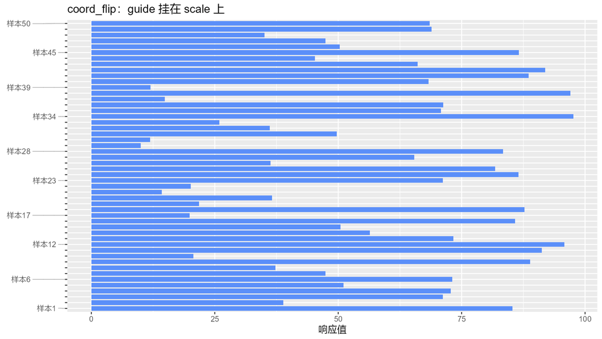

coord_flip() 之后：x 轴标签变成竖直轴，guide 挂在 scale 上

```r
ggplot(df50, aes(x = sample, y = value)) +
  geom_col(fill = "#5B8FF9", width = 0.8) +
  scale_x_discrete(guide = guide_axis_smart(n = 10, nrow = 2)) +
  coord_flip() +
  labs(x = NULL, y = "响应值", title = "coord_flip：guide 挂在 scale 上") +
  theme_grey(base_size = 12)
```

等价写法是 `guides(y = guide_axis_smart(...))`——翻转后分类轴的 guide 槽位换到了 `y`。

## theme：文字样式会继承

标签的颜色、字号、字体、粗细都从主题的 `axis.text.x` / `axis.text.y` 继承，所以 `theme()` 的写法不用改：

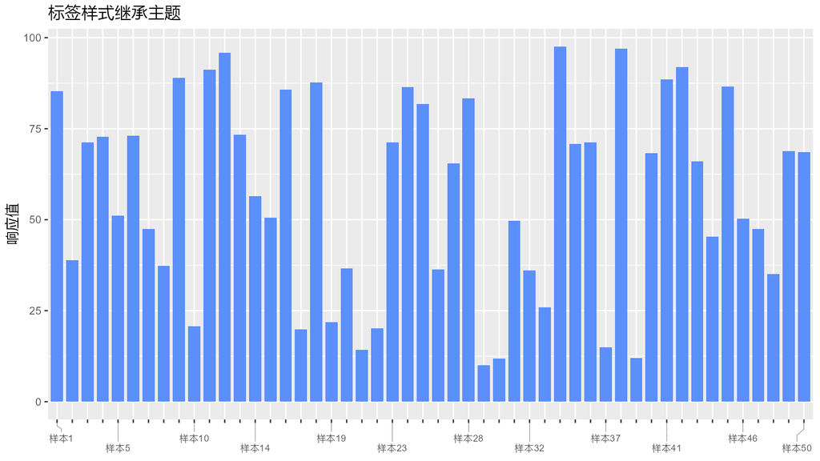

标签样式从 axis.text.x 继承：灰色、9 pt

```r
ggplot(df50, aes(x = sample, y = value)) +
  geom_col(fill = "#5B8FF9", width = 0.8) +
  guides(x = guide_axis_smart(n = 12, nrow = 2)) +
  labs(x = NULL, y = "响应值", title = "标签样式继承主题") +
  theme_grey(base_size = 13) +
  theme(axis.text.x = element_text(colour = "grey30", size = 9))
```

**不要**再写 `theme(axis.text.x = element_blank())`——guide 会原样继承这个”空白”元素，标签就全没了。

# 算法原理

这一节的图是手工画的示意图，用来解释 guide 内部发生了什么。

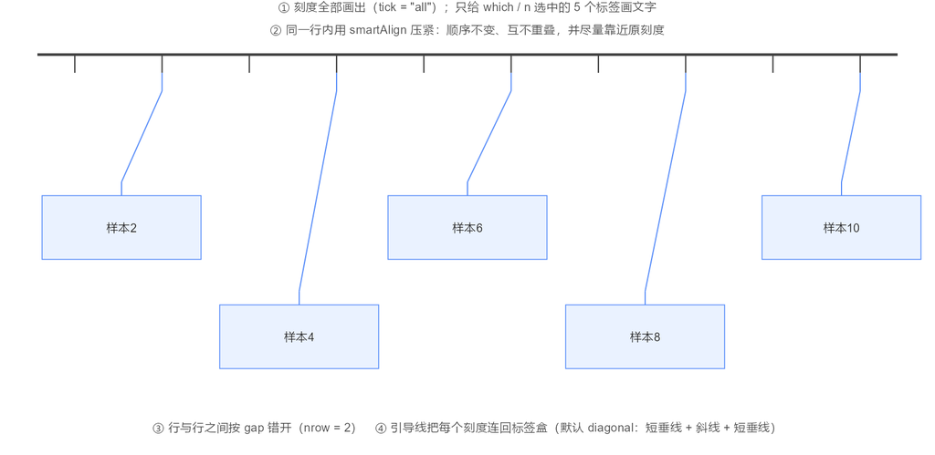

guide_axis_smart() 的一次排布：选出标签 → 同一行内压紧 → 多行错开 → 引导线连回刻度

```r
tick_x <- seq(0.08, 0.92, length.out = 10)
lab <- data.frame(
  tick_x = tick_x[c(2, 4, 6, 8, 10)],
  center = c(0.13, 0.32, 0.50, 0.69, 0.90),
  row = c(1, 2, 1, 2, 1),
  text = paste0("样本", c(2, 4, 6, 8, 10))
)
lab$y <- ifelse(lab$row == 1, 0.50, 0.26)
lab$ymin <- lab$y - 0.07
lab$ymax <- lab$y + 0.07
lab$xmin <- lab$center - 0.085
lab$xmax <- lab$center + 0.085

ggplot() +
  # 轴线与全部刻度
  geom_segment(aes(x = 0.04, xend = 0.96, y = 0.88, yend = 0.88),
               linewidth = 1, colour = "grey25") +
  geom_segment(data = data.frame(x = tick_x),
               aes(x = x, xend = x, y = 0.88, yend = 0.84),
               linewidth = 0.5, colour = "grey25") +
  # 引导线：短垂线 + 斜线 + 短垂线（anno_mark 几何）
  geom_segment(data = lab, aes(x = tick_x, xend = tick_x, y = 0.84, yend = 0.80),
               linewidth = 0.45, colour = "#5B8FF9") +
  geom_segment(data = lab, aes(x = tick_x, xend = center, y = 0.80, yend = y + 0.10),
               linewidth = 0.45, colour = "#5B8FF9") +
  geom_segment(data = lab, aes(x = center, xend = center, y = y + 0.10, yend = y + 0.07),
               linewidth = 0.45, colour = "#5B8FF9") +
  # 标签盒
  geom_rect(data = lab, aes(xmin = xmin, xmax = xmax, ymin = ymin, ymax = ymax),
            fill = "#EAF2FF", colour = "#5B8FF9", linewidth = 0.35) +
  geom_text(data = lab, aes(x = center, y = y, label = text),
            size = 3.4, colour = "grey15") +
  # 注释
  annotate("text", x = 0.5, y = 0.995, vjust = 1, size = 3.5, colour = "grey30",
           label = "① 刻度全部画出（tick = \"all\"）；只给 which / n 选中的 5 个标签画文字") +
  annotate("text", x = 0.5, y = 0.945, vjust = 1, size = 3.5, colour = "grey30",
           label = "② 同一行内用 smartAlign 压紧：顺序不变、互不重叠，并尽量靠近原刻度") +
  annotate("text", x = 0.5, y = 0.07, vjust = 1, size = 3.5, colour = "grey30",
           label = "③ 行与行之间按 gap 错开（nrow = 2）　④ 引导线把每个刻度连回标签盒（默认 diagonal：短垂线 + 斜线 + 短垂线）") +
  coord_cartesian(xlim = c(0, 1), ylim = c(0, 1), expand = FALSE) +
  theme_void()
```

一次绘制大致经过下面几步：

1. **量宽度**：对每个要显示的标签，用 `grid` 的文本度量算出标签盒的宽度（含 `padding`），再换算成面板内的相对宽度。
2. **一维压紧（`smart_align()`）**：同一行里，标签盒按原顺序排列；如果相邻盒子重叠，就把它们向两侧”推”开，直到满足最小间距。算法保证顺序不变、互不重叠，并且推开的距离尽量小。这正是 `circlize::smartAlign` 的一维防重叠算法（本包做了精确移植）。
3. **轨道分配（`smart_stack()`）**：先决定用几行（y 轴就是几列）——**能一行放下就一行**；总宽超过一行、或标签集中挤在轴的一小段里（按这一簇的跨度估算）时才分成多行，上限 `max_nrow`。然后逐行把标签盒分配进去并做压紧，行间距由 `gap` 控制；更复杂的盒式落位借助 `box_arrange()`（`ComplexHeatmap::BoxArrange` 的移植）。实在放不下时按优先级丢弃标签，**绝不**画出重叠的标签。
4. **两阶段尺寸**：`ggplot2` 构建 guide 时还拿不到面板的真实宽度，所以先按设备尺寸估计行数并**预留**这么多行的高度；真正绘制时再用面板的真实宽度重算精确布局。这就是为什么行数会随图形尺寸/设备改变，也是 `panel_width` 参数存在的理由。
5. **画引导线**：默认的 `"diagonal"` 样式是”短垂线 → 斜线 → 短垂线”：从刻度先垂直于轴走一小段（`link_length`），再用斜线跨到标签所在行，最后垂直落到标签盒；旋转或平移的幅度由标签被推开的距离决定。

底层三个函数 `smart_align()`、`box_arrange()`、`smart_stack()` 都是导出函数，可以单独调用（参数见 `?smart_align` 等），guide 只是它们的一层封装。

# 已知限制与调参建议

- **它只能挑选已有的刻度，不会新增刻度。** 如果某个类别不在 scale 的 breaks 里，`which` 就选不到它——先用 `scale_x_discrete(breaks = ...)` 把它放进去。
- **自动分行是”按需”的。** 能一行放下就一行（贴轴摊开，最接近 `anno_mark()` 的观感）；总宽超了、或标签集中在一段里才分行，上限 `max_nrow` 条轨道。想要纯单行 anno_mark 风格就显式写 `nrow = 1`。
- **显示数量可能少于请求数量。** 面板太窄、行数不够时，guide 会按优先级丢弃标签，宁可少画也不画重叠。想多显示就加 `nrow`、放大图形，或调小 `padding`/`gap`。
- **`which = NULL` 且 `n = NULL` 时会自动抽稀。** 全部标签的总宽度超过 `max_nrow` 条轨道能容纳的范围时，guide 会自动等距抽稀并通过 `cli` 提示一次；`options(ggsmartext.quiet = TRUE)` 可静音。建议始终显式写 `n =` 或 `which =`，让”显示哪些标签”由你决定，而不是由屏幕尺寸决定。
- **自动行数依赖设备尺寸。** 同一个图在 RStudio 窗口和 1600×900 的 PNG 里可能行数不同。需要结果稳定时，显式写 `nrow`，或用 `panel_width` 告诉 guide 面板大概多宽（单位 cm）。
- **`angle` 一般配 `nrow = 1`。** 旋转后的标签会占用更多纵向空间（guide 按旋转后的包围盒预留高度），多行再叠加旋转通常不划算。
- **不要用 `axis.text.*` 把标签设为空白**，guide 会继承成”没有文字”；要隐藏标签请直接不用 guide 或改画别的。
- **`coord_flip()` 已 superseded**：新代码建议直接把分类变量映射到 y 轴。旧代码里请把 guide 挂在 scale 上（`scale_x_discrete(guide = ...)`）或改用 `guides(y = ...)`，`guides(x = ...)` 在翻转后会挂到数值轴上。
- **`extend > 0` 时才需要 `plot.margin`**：默认 `extend = 0` 时标签不会越出面板，不会被画布裁切；一旦调大 `extend`，就要给 `theme(plot.margin = ...)` 留出相应边距。
- **自定义副轴**：`sec.axis = dup_axis(guide = guide_axis_smart(...))` 已经验证可用（见”集中标注与热图标注”一节）；更复杂的副轴请先小图验证。
- 性能上无需担心：标签度量在构建期一次完成，200 个类别也是交互级速度。

# 会话信息

```r
cat("ggplot2:", as.character(packageVersion("ggplot2")), "\n")
```

```
#> ggplot2: 4.0.3
```

```r
cat("ggsmartext:", as.character(packageVersion("ggsmartext")), "\n")
```

```
#> ggsmartext: 0.0.1
```

```r
cat("R:", R.version.string, "\n")
```

```
#> R: R version 4.5.1 (2025-06-13 ucrt)
```